# Population_vs_Deer

# Data 589 Project

## Load .Rdata

```r
load("data/deer_data.Rdata")

pop_clean<-pop_im
str(pop_clean)
```

```
List of 10
 $ v     : num [1:2195, 1:2962] NaN NaN NaN NaN NaN NaN NaN NaN NaN NaN ...
 $ dim   : int [1:2] 2195 2962
 $ xrange: num [1:2] 34901 1883761
 $ yrange: num [1:2] 365690 1735956
 $ xstep : num 624
 $ ystep : num 624
 $ xcol  : num [1:2962] 35213 35837 36462 37086 37710 ...
 $ yrow  : num [1:2195] 366002 366627 367251 367875 368499 ...
 $ type  : chr "real"
 $ units :List of 3
  ..$ singular  : chr "unit"
  ..$ plural    : chr "units"
  ..$ multiplier: num 1
  ..- attr(*, "class")= chr "unitname"
 - attr(*, "class")= chr "im"
```

## Baseline Modeling

```r
library(spatstat)
#null model
model_null <- ppm(deer_ppp ~ 1)
model_pop <- ppm(deer_ppp ~ pop, covariates = list(pop = pop_im))
summary(model_pop)
```

```
Point process model
Fitted to data: deer_ppp
Fitting method: maximum likelihood (Berman-Turner approximation)
Model was fitted using glm()
Algorithm converged
Call:
ppm.formula(Q = deer_ppp ~ pop, covariates = list(pop = pop_im))
Edge correction: "border"
    [border correction distance r = 0 ]
--------------------------------------------------------------------------------
Quadrature scheme (Berman-Turner) = data + dummy + weights

Data pattern:
Planar point pattern:  11002 points
Average intensity 1.16e-08 points per square unit
Window: polygonal boundary
378 separate polygons (2 holes)
                   vertices         area relative.area
polygon 1              5454 889865000000      9.38e-01
polygon 2                19     11135700      1.17e-05
polygon 3                 6      1679950      1.77e-06
polygon 4                59    375017000      3.95e-04
polygon 5                25     54751800      5.77e-05
polygon 6                 5      1220870      1.29e-06
polygon 7                 8      6790020      7.16e-06
polygon 8                63    151745000      1.60e-04
polygon 9                12     10733900      1.13e-05
polygon 10                3       732692      7.73e-07
polygon 11               10      6152880      6.49e-06
polygon 12                4       808047      8.52e-07
polygon 13               15     12418500      1.31e-05
polygon 14                7      2619570      2.76e-06
polygon 15               24     19177800      2.02e-05
polygon 16                4       637359      6.72e-07
polygon 17                7      1083120      1.14e-06
polygon 18                4       630075      6.64e-07
polygon 19               16     23094400      2.44e-05
polygon 20                4       740351      7.81e-07
polygon 21               28     31469400      3.32e-05
polygon 22                5      1243830      1.31e-06
```

[output cut: 780 more lines]

```
                  Zval
(Intercept) -915.12913
pop           52.13709

----------- gory details -----

Fitted regular parameters (theta):
 (Intercept)          pop
-14.51601470   0.04123541

Fitted exp(theta):
 (Intercept)          pop
4.963350e-07 1.042097e+00
Problem:
 Values of the covariate 'pop' were NA or undefined at 75% (22743 out of 30177) of the quadrature points
```

```
Problem:  Values of the covariate ‘pop’ were NA or undefined at 75% (22743 out of 30177) of the quadrature points
```

## Compute and plot rho function

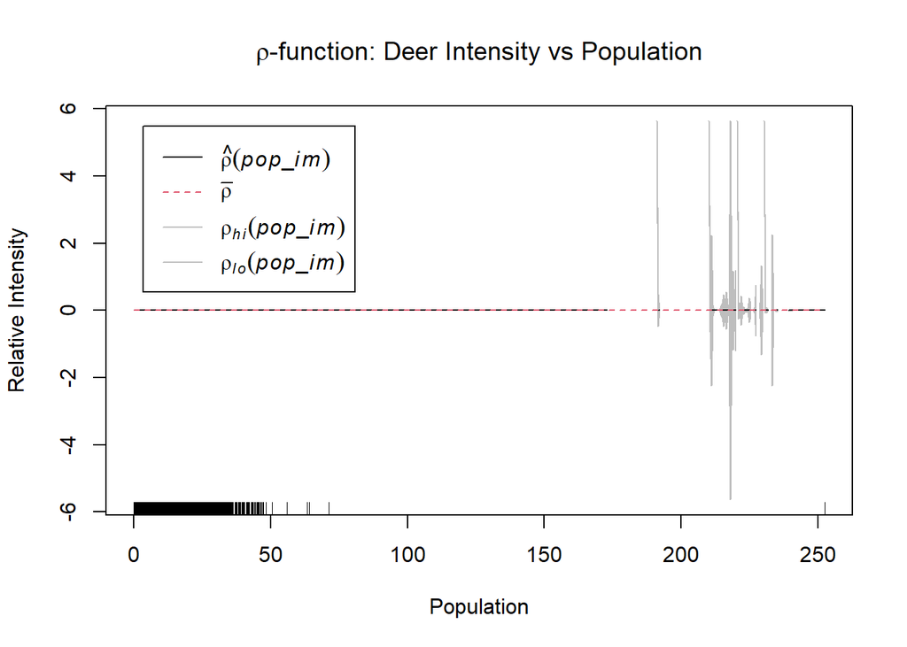

```r
library(spatstat)

# Compute rho function: expected relative intensity vs. population
rho_pop <- rhohat(deer_ppp, covariate = pop_im)
# Plot
plot(rho_pop,
     main = expression(paste(rho, "-function: Deer Intensity vs Population")),
     xlab = "Population",
     ylab = "Relative Intensity")
```

The ρ-function suggests **population has minimal or no clear effect** on deer intensity in most areas.

Where population is high (above 200), deer are rare, and intensity estimates become noisy due to **lack of data**.

Most deer are observed in areas with **low to moderate population**, consistent with expectations of deer avoiding highly urbanized or densely populated regions.

## Model Comparison: Compare with null model

```r
# Model summary
summary(model_pop)
```

```
Point process model
Fitted to data: deer_ppp
Fitting method: maximum likelihood (Berman-Turner approximation)
Model was fitted using glm()
Algorithm converged
Call:
ppm.formula(Q = deer_ppp ~ pop, covariates = list(pop = pop_im))
Edge correction: "border"
    [border correction distance r = 0 ]
--------------------------------------------------------------------------------
Quadrature scheme (Berman-Turner) = data + dummy + weights

Data pattern:
Planar point pattern:  11002 points
Average intensity 1.16e-08 points per square unit
Window: polygonal boundary
378 separate polygons (2 holes)
                   vertices         area relative.area
polygon 1              5454 889865000000      9.38e-01
polygon 2                19     11135700      1.17e-05
polygon 3                 6      1679950      1.77e-06
polygon 4                59    375017000      3.95e-04
polygon 5                25     54751800      5.77e-05
polygon 6                 5      1220870      1.29e-06
polygon 7                 8      6790020      7.16e-06
polygon 8                63    151745000      1.60e-04
polygon 9                12     10733900      1.13e-05
polygon 10                3       732692      7.73e-07
polygon 11               10      6152880      6.49e-06
polygon 12                4       808047      8.52e-07
polygon 13               15     12418500      1.31e-05
polygon 14                7      2619570      2.76e-06
polygon 15               24     19177800      2.02e-05
polygon 16                4       637359      6.72e-07
polygon 17                7      1083120      1.14e-06
polygon 18                4       630075      6.64e-07
polygon 19               16     23094400      2.44e-05
polygon 20                4       740351      7.81e-07
polygon 21               28     31469400      3.32e-05
polygon 22                5      1243830      1.31e-06
```

[output cut: 780 more lines]

```
                  Zval
(Intercept) -915.12913
pop           52.13709

----------- gory details -----

Fitted regular parameters (theta):
 (Intercept)          pop
-14.51601470   0.04123541

Fitted exp(theta):
 (Intercept)          pop
4.963350e-07 1.042097e+00
Problem:
 Values of the covariate 'pop' were NA or undefined at 75% (22743 out of 30177) of the quadrature points
```

```r
# Likelihood ratio test (compare with null model)
anova(model_null, model_pop, test = "LRT")
```

```
Analysis of Deviance Table

Model 1: ~1      Poisson
Model 2: ~pop    Poisson
   Npar Df Deviance  Pr(>Chi)
1 22744
2 22745  1   1918.2 < 2.2e-16 ***
---
Signif. codes:  0 '***' 0.001 '**' 0.01 '*' 0.05 '.' 0.1 ' ' 1
```

```r
# Quadrat test (statistical + visual)
qtest_pop <- quadrat.test(model_pop, nx = 5, ny = 5)
print(qtest_pop)
```

```
    Chi-squared test of fitted Poisson model 'model_pop' using quadrat
    counts

data:  data from model_pop
X2 = NaN, df = 19, p-value = NA
alternative hypothesis: two.sided

Quadrats: 21 tiles (irregular windows)
```

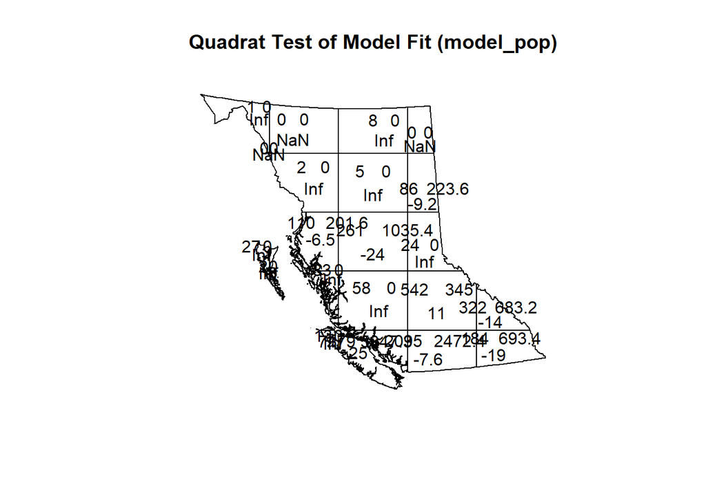

```r
plot(qtest_pop, main = "Quadrat Test of Model Fit (model_pop)")
```

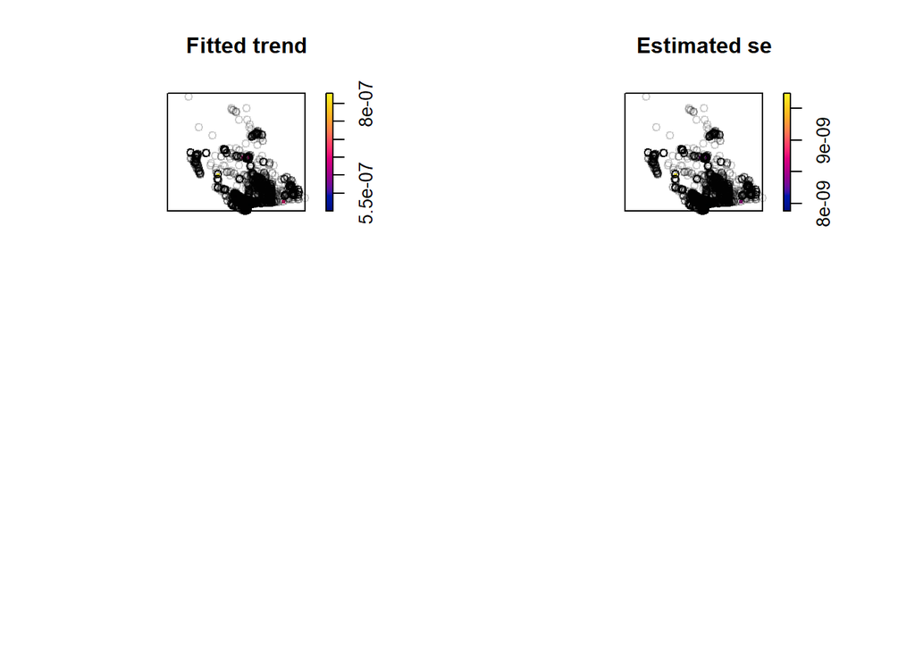

```r
# Residual diagnostic plots
par(mfrow = c(2, 2))
plot(model_pop, which = 1:4)

# Lurking variable plot
par(mfrow = c(1, 1))
```

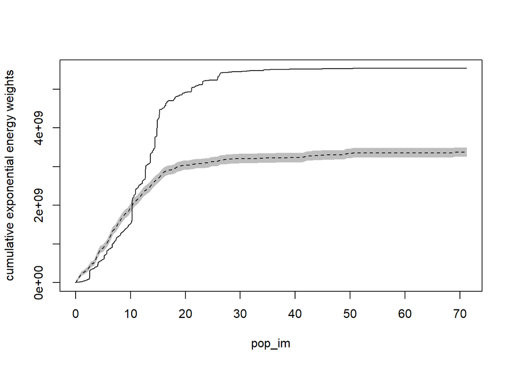

```r
lurking(model_pop, covariate = pop_im, cumulative = TRUE)
```

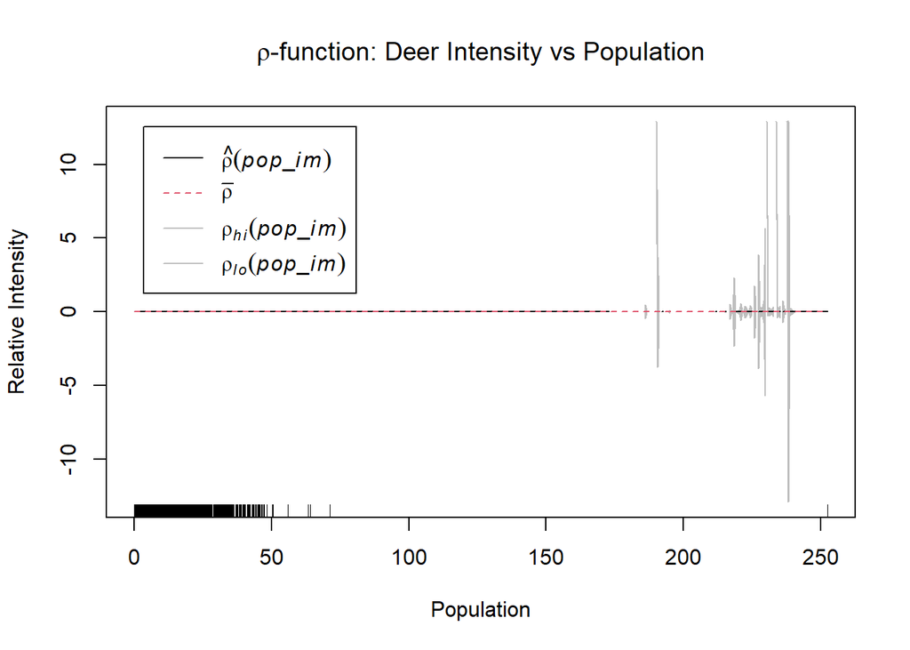

```r
# Rho function (nonparametric covariate check)
rho_pop <- rhohat(deer_ppp, covariate = pop_im)
plot(rho_pop,
     main = expression(paste(rho, "-function: Deer Intensity vs Population")),
     xlab = "Population", ylab = "Relative Intensity")
```

```r
# AIC comparison
AIC(model_null, model_pop)
```

```
[1] 424064.5
```

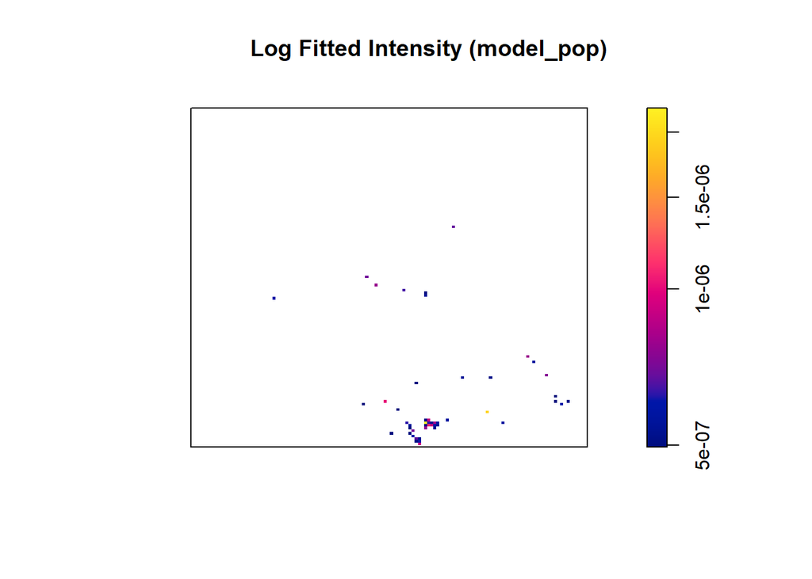

```r
# Visualise fitted intensity (log scale)
plot(predict(model_pop),
     log = TRUE,
     main = "Log Fitted Intensity (model_pop)",
     n = 2048)
```

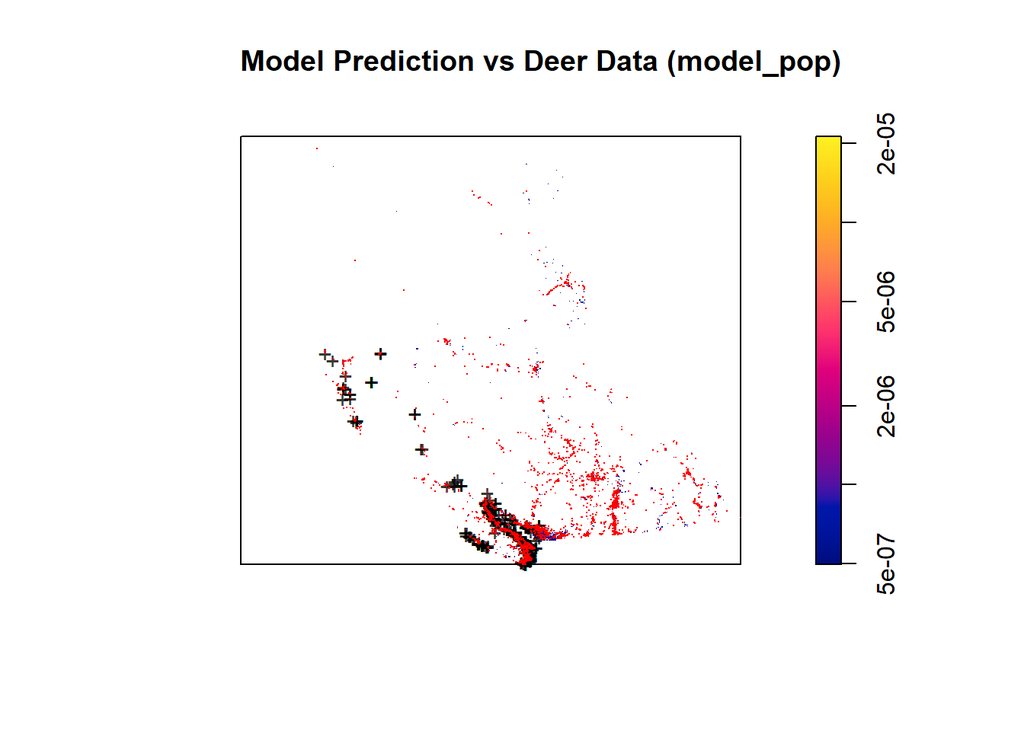

```r
# Overlay deer points on predicted intensity surface
plot(predict(model_pop, n = 512),
     log = TRUE,
     main = "Model Prediction vs Deer Data (model_pop)")
plot(deer_ppp, add = TRUE, cols = "red", pch = ".")
```

```r
# Plot effect of population (log-intensity scale)
effectfun(model_pop, "pop", se.fit = FALSE,
          main = "Effect of Population on Log Intensity (model_pop)")
```

```
Function value object (class 'fv')
for the function pop -> lambda(pop)
..............................................
       Math.label       Description
pop    pop              value of covariate pop
lambda hat(lambda)(pop) fitted intensity
..............................................
Default plot formula:  lambda~pop
where "." stands for 'lambda'
Recommended range of argument pop: [0, 252.47]
Available range of argument pop: [0, 252.47]
```

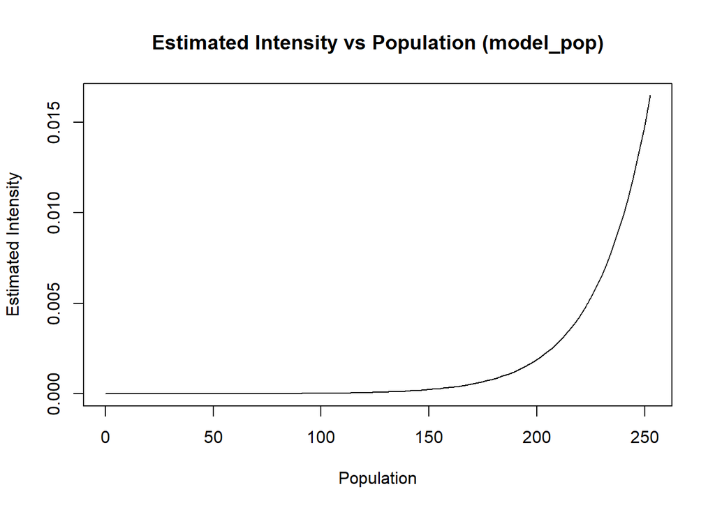

```r
# Plot effect of population (intensity scale)
curve(exp(coef(model_pop)[1] + coef(model_pop)[2] * x),
      from = min(pop_im$v, na.rm = TRUE),
      to = max(pop_im$v, na.rm = TRUE),
      xlab = "Population", ylab = "Estimated Intensity",
      main = "Estimated Intensity vs Population (model_pop)")
```

## Summary on model_pop

The original Poisson point process model (`model_pop`) estimates deer intensity as a function of raw population values (`pop_im`). The population coefficient is positive (0.041), indicating a weak but significant increase in deer intensity with increasing population. The effect is statistically significant based on the likelihood ratio test (Deviance = 1918.2, p < 2.2e-16), although the magnitude of the effect is modest (about a 4.2% increase in intensity per unit increase in population).

However, the model encountered substantial technical issues due to data quality. Specifically, 75% of the quadrature points had missing (`NA`) or undefined population values, which led to a large portion of points being discarded during model fitting. Consequently, the chi-squared goodness-of-fit test could not be computed (X² = NaN), and additional warnings were issued about illegal points and tile coverage gaps. This severely limits confidence in the model’s reliability and interpretability.

Overall, while the covariate effect remains statistically significant, the lack of data coverage and unstable diagnostics highlight the need for smoothing or interpolation (e.g., using `Smooth()` or kriging) to produce a more robust and usable model.

## Use smoothing instead

Smoothing was applied to the population covariate to address the presence of missing values (`NA` or `NaN`) and to ensure that valid population values were available across the entire spatial domain required by the point process model. Since the original covariate was sparse or only available at selected locations (e.g., via co-Kriging at quadrature points), Gaussian smoothing provided a principled way to interpolate across space, resulting in a continuous and complete surface. This allowed for valid model fitting and diagnostic procedures, such as evaluating the covariate’s effect on deer intensity using `ppm()` and `rhohat()`, without computational errors or data gaps.

## Apply Smoothing

```r
pop_smoothed <- Smooth(pop_im, sigma = 2500)

# Replace non-positive or NA values with a small positive value (e.g., 1e-6)
pop_smoothed$v[is.na(pop_smoothed$v) | pop_smoothed$v <= 0] <- 0
```

## Rho Plot

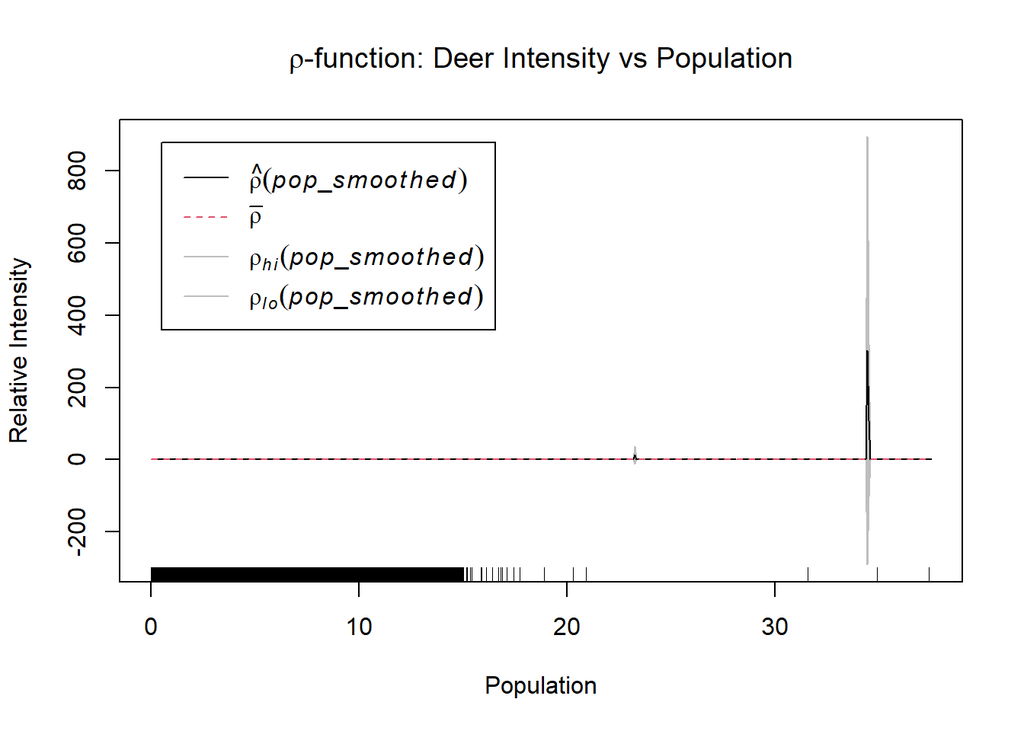

```r
rho_pop <- rhohat(deer_ppp, covariate = pop_smoothed)

# Plot
plot(rho_pop,
     main = expression(paste(rho, "-function: Deer Intensity vs Population")),
     xlab = "Population",
     ylab = "Relative Intensity")
```

## Modelling with smoothed population

```r
library(spatstat)

# Smooth the co-Kriged population covariate
pop_filled <- Smooth(pop_clean, sigma = 2500)  # Adjust sigma if needed

# Use the smoothed version in ppm()
model_fixed <- ppm(deer_ppp ~ pop, covariates = list(pop = pop_filled))
model_fixed
```

```
Nonstationary Poisson process
Fitted to point pattern dataset 'deer_ppp'

Log intensity:  ~pop

Fitted trend coefficients:
(Intercept)         pop
-18.3917597   0.2161912

               Estimate         S.E.     CI95.lo     CI95.hi Ztest       Zval
(Intercept) -18.3917597 0.0101385566 -18.4116309 -18.3718885   *** -1814.0412
pop           0.2161912 0.0008780705   0.2144702   0.2179122   ***   246.2117
```

## Modelling: Compare with null model

```r
library(spatstat)

# Model summary
summary(model_fixed)
```

```
Point process model
Fitted to data: deer_ppp
Fitting method: maximum likelihood (Berman-Turner approximation)
Model was fitted using glm()
Algorithm converged
Call:
ppm.formula(Q = deer_ppp ~ pop, covariates = list(pop = pop_filled))
Edge correction: "border"
    [border correction distance r = 0 ]
--------------------------------------------------------------------------------
Quadrature scheme (Berman-Turner) = data + dummy + weights

Data pattern:
Planar point pattern:  11002 points
Average intensity 1.16e-08 points per square unit
Window: polygonal boundary
378 separate polygons (2 holes)
                   vertices         area relative.area
polygon 1              5454 889865000000      9.38e-01
polygon 2                19     11135700      1.17e-05
polygon 3                 6      1679950      1.77e-06
polygon 4                59    375017000      3.95e-04
polygon 5                25     54751800      5.77e-05
polygon 6                 5      1220870      1.29e-06
polygon 7                 8      6790020      7.16e-06
polygon 8                63    151745000      1.60e-04
polygon 9                12     10733900      1.13e-05
polygon 10                3       732692      7.73e-07
polygon 11               10      6152880      6.49e-06
polygon 12                4       808047      8.52e-07
polygon 13               15     12418500      1.31e-05
polygon 14                7      2619570      2.76e-06
polygon 15               24     19177800      2.02e-05
polygon 16                4       637359      6.72e-07
polygon 17                7      1083120      1.14e-06
polygon 18                4       630075      6.64e-07
polygon 19               16     23094400      2.44e-05
polygon 20                4       740351      7.81e-07
polygon 21               28     31469400      3.32e-05
polygon 22                5      1243830      1.31e-06
```

[output cut: 775 more lines]

```
-18.3917597   0.2161912

               Estimate         S.E.     CI95.lo     CI95.hi Ztest       Zval
(Intercept) -18.3917597 0.0101385566 -18.4116309 -18.3718885   *** -1814.0412
pop           0.2161912 0.0008780705   0.2144702   0.2179122   ***   246.2117

----------- gory details -----

Fitted regular parameters (theta):
(Intercept)         pop
-18.3917597   0.2161912

Fitted exp(theta):
 (Intercept)          pop
1.029343e-08 1.241340e+00
```

```r
# Likelihood ratio test (compare with null model)
anova(model_null, model_fixed, test = "LRT")
```

```
Analysis of Deviance Table

Model 1: ~1      Poisson
Model 2: ~pop    Poisson
  Npar Df Deviance  Pr(>Chi)
1    1
2    2  1    15797 < 2.2e-16 ***
---
Signif. codes:  0 '***' 0.001 '**' 0.01 '*' 0.05 '.' 0.1 ' ' 1
```

```r
# Quadrat test (statistical + visual)
qtest <- quadrat.test(model_fixed, nx = 5, ny = 5)
print(qtest)
```

```
    Chi-squared test of fitted Poisson model 'model_fixed' using quadrat
    counts

data:  data from model_fixed
X2 = 57482, df = 19, p-value < 2.2e-16
alternative hypothesis: two.sided

Quadrats: 21 tiles (irregular windows)
```

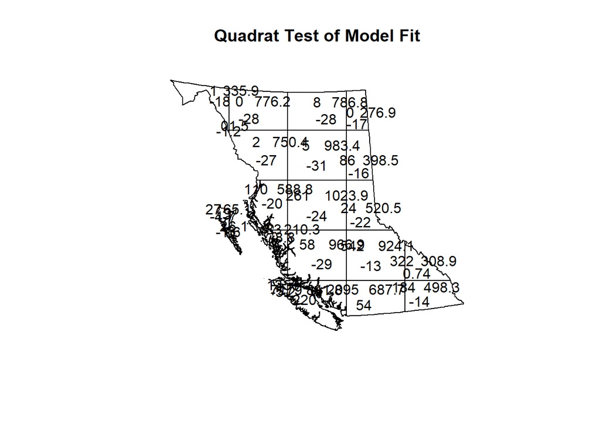

```r
plot(qtest, main = "Quadrat Test of Model Fit")
```

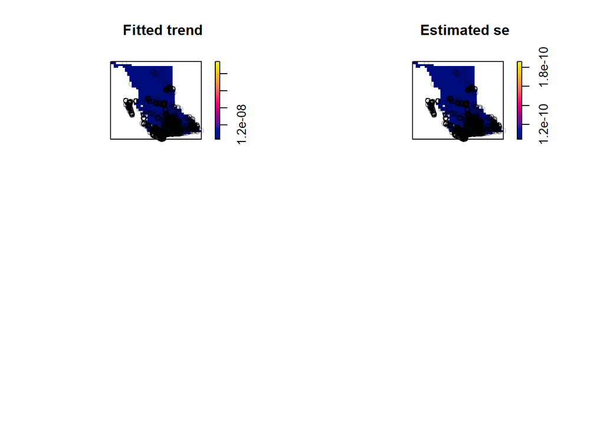

```r
# Residual diagnostic plots
par(mfrow = c(2, 2))
plot(model_fixed, which = 1:4)

# Lurking variable plot
par(mfrow = c(1, 1))
```

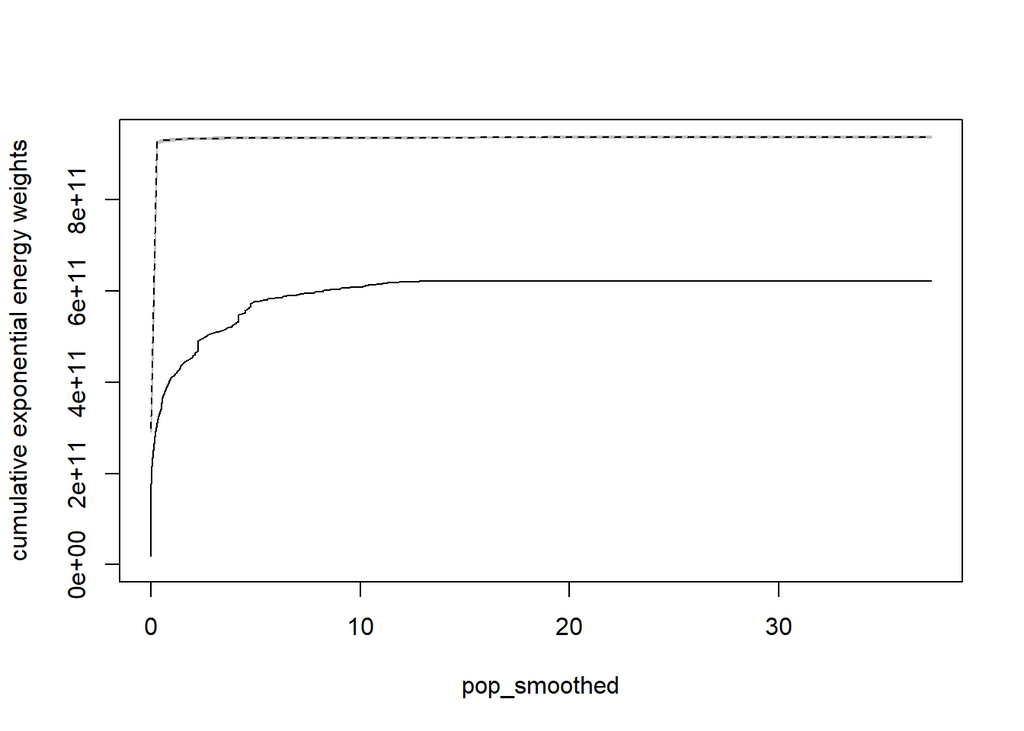

```r
lurking(model_fixed, covariate = pop_smoothed, cumulative = TRUE)
```

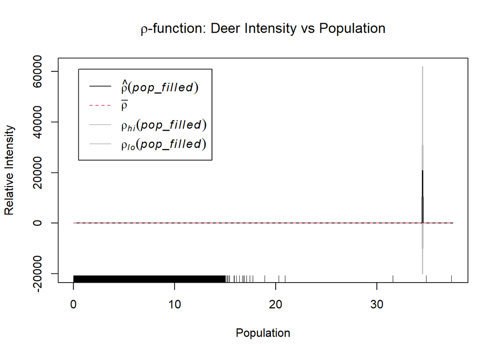

```r
# Rho function (nonparametric covariate check)
rho_pop <- rhohat(deer_ppp, covariate = pop_filled)
plot(rho_pop,
     main = expression(paste(rho, "-function: Deer Intensity vs Population")),
     xlab = "Population", ylab = "Relative Intensity")
```

```r
# AIC comparison
AIC(model_null, model_fixed)
```

```
[1] 424064.5
```

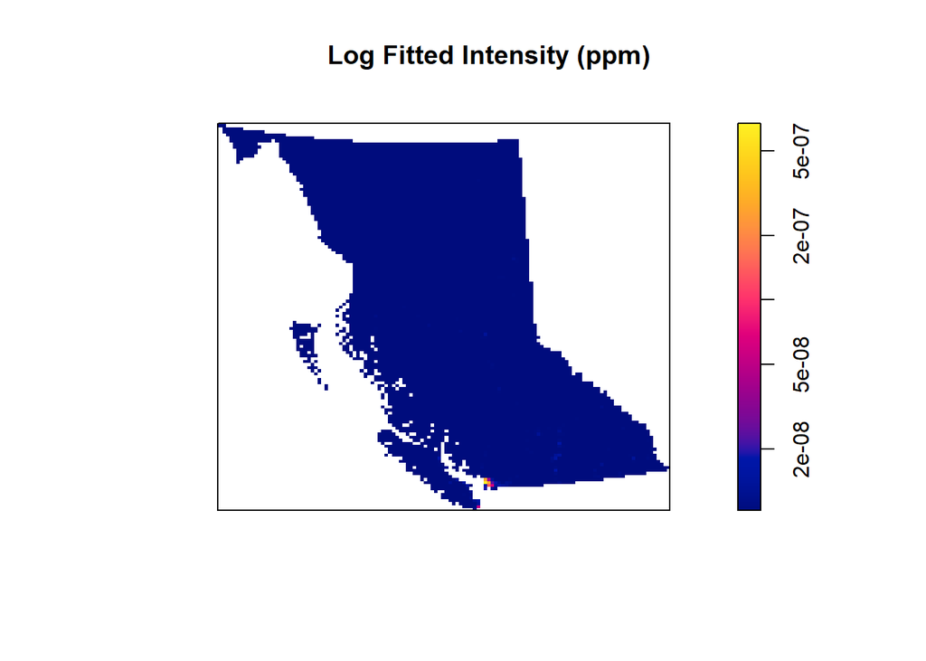

```r
# Visualise fitted intensity (log scale)
plot(predict(model_fixed),
     log = TRUE,
     main = "Log Fitted Intensity (ppm)",
     n = 2048)
```

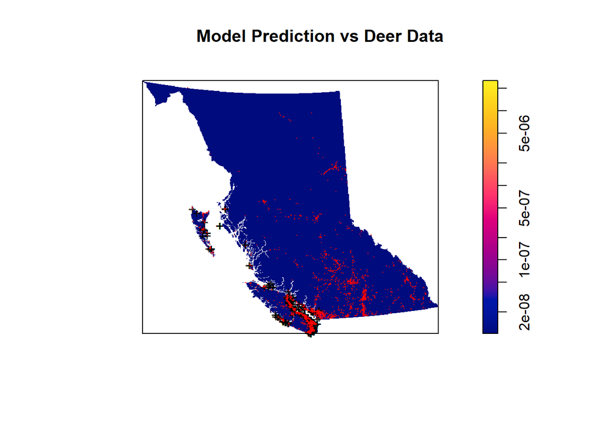

```r
# Overlay deer points on predicted intensity surface
plot(predict(model_fixed, n = 512),
     log = TRUE,
     main = "Model Prediction vs Deer Data")
plot(deer_ppp, add = TRUE, cols = "red", pch = ".")
```

```r
# Plot effect of population (log-intensity scale)
effectfun(model_fixed, "pop", se.fit = FALSE,
          main = "Effect of Population on Log Intensity")
```

```
Function value object (class 'fv')
for the function pop -> lambda(pop)
..............................................
       Math.label       Description
pop    pop              value of covariate pop
lambda hat(lambda)(pop) fitted intensity
..............................................
Default plot formula:  lambda~pop
where "." stands for 'lambda'
Recommended range of argument pop: [-5.3442e-14, 37.486]
Available range of argument pop: [-5.3442e-14, 37.486]
```

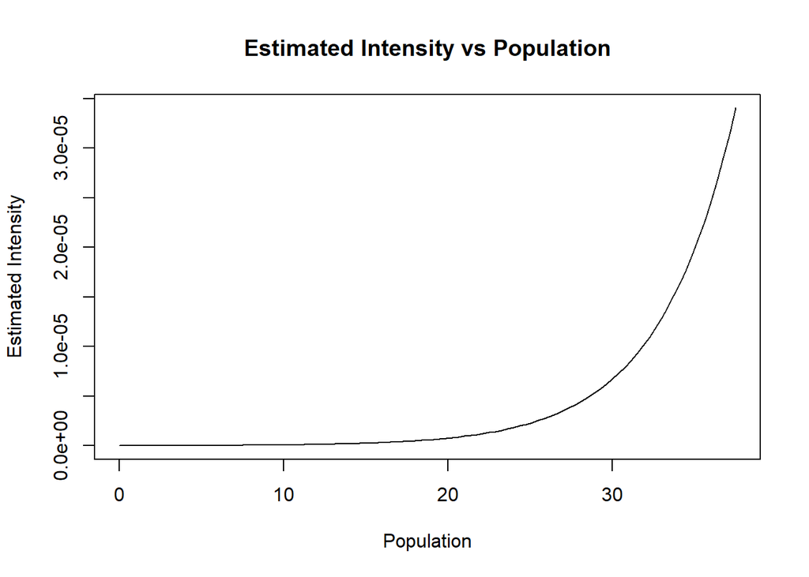

```r
# Plot effect of population (intensity scale)
curve(exp(coef(model_fixed)[1] + coef(model_fixed)[2] * x),
      from = min(pop_filled$v, na.rm = TRUE),
      to = max(pop_filled$v, na.rm = TRUE),
      xlab = "Population", ylab = "Estimated Intensity",
      main = "Estimated Intensity vs Population")
```

## Summary on model_fixed (model with smoothed population)

The fitted model `model_fixed` is a Poisson point process model estimating deer intensity as a function of population. The population coefficient is 0.216, indicating that deer intensity increases by about 24% per unit increase in population. The effect is highly significant (p < 2.2e-16), confirming that population improves model fit. However, a chi-squared goodness-of-fit test shows lack of fit (χ² = 57,482, p < 2.2e-16), suggesting population alone does not fully explain the spatial pattern. Additional covariates or spatial structure may be needed.

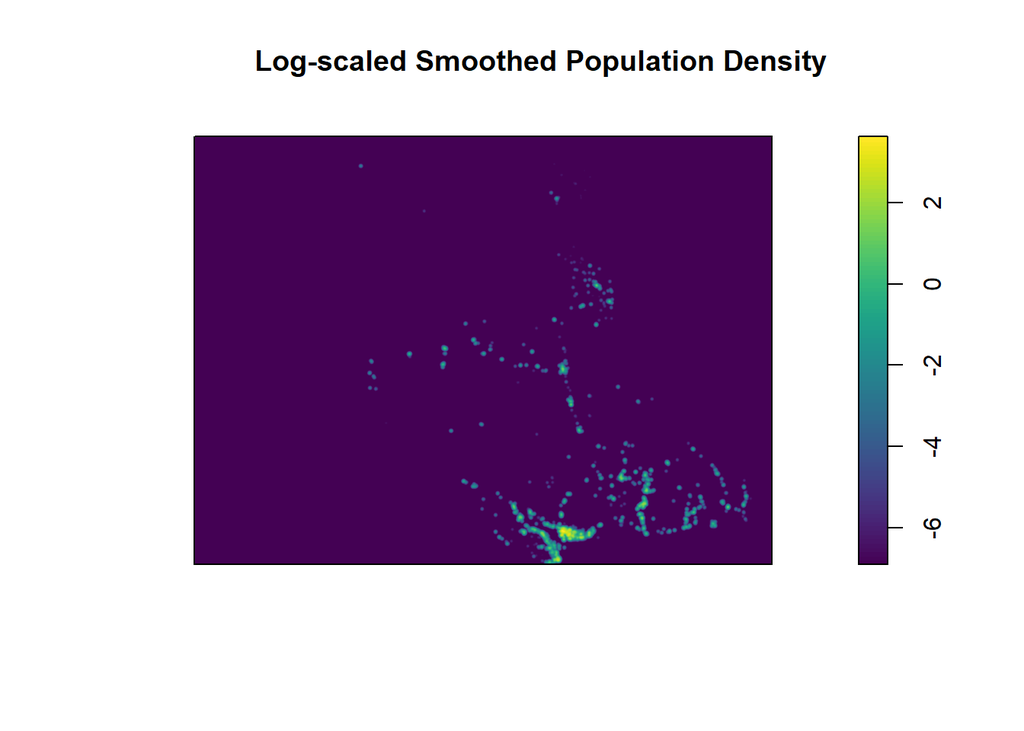

```r
library(spatstat)
library(viridis)
pop_log <- eval.im(log(pop_smoothed + 1e-3))

# Step 2: Visualize the log-transformed covariate
plot(pop_log,
     main = "Log-scaled Smoothed Population Density",
     col = viridis(100))
```

```r
# Step 3: Fit Poisson point process model using log-transformed population
model_pop_log <- ppm(deer_ppp ~ pop, covariates = list(pop = pop_log))
# Step 4: Summarize the model
summary(model_pop_log)
```

```
Point process model
Fitted to data: deer_ppp
Fitting method: maximum likelihood (Berman-Turner approximation)
Model was fitted using glm()
Algorithm converged
Call:
ppm.formula(Q = deer_ppp ~ pop, covariates = list(pop = pop_log))
Edge correction: "border"
    [border correction distance r = 0 ]
--------------------------------------------------------------------------------
Quadrature scheme (Berman-Turner) = data + dummy + weights

Data pattern:
Planar point pattern:  11002 points
Average intensity 1.16e-08 points per square unit
Window: polygonal boundary
378 separate polygons (2 holes)
                   vertices         area relative.area
polygon 1              5454 889865000000      9.38e-01
polygon 2                19     11135700      1.17e-05
polygon 3                 6      1679950      1.77e-06
polygon 4                59    375017000      3.95e-04
polygon 5                25     54751800      5.77e-05
polygon 6                 5      1220870      1.29e-06
polygon 7                 8      6790020      7.16e-06
polygon 8                63    151745000      1.60e-04
polygon 9                12     10733900      1.13e-05
polygon 10                3       732692      7.73e-07
polygon 11               10      6152880      6.49e-06
polygon 12                4       808047      8.52e-07
polygon 13               15     12418500      1.31e-05
polygon 14                7      2619570      2.76e-06
polygon 15               24     19177800      2.02e-05
polygon 16                4       637359      6.72e-07
polygon 17                7      1083120      1.14e-06
polygon 18                4       630075      6.64e-07
polygon 19               16     23094400      2.44e-05
polygon 20                4       740351      7.81e-07
polygon 21               28     31469400      3.32e-05
polygon 22                5      1243830      1.31e-06
```

[output cut: 775 more lines]

```
-14.6402597   0.7849321

               Estimate        S.E.     CI95.lo     CI95.hi Ztest       Zval
(Intercept) -14.6402597 0.009611724 -14.6590983 -14.6214210   *** -1523.1669
pop           0.7849321 0.002893810   0.7792603   0.7906038   ***   271.2452

----------- gory details -----

Fitted regular parameters (theta):
(Intercept)         pop
-14.6402597   0.7849321

Fitted exp(theta):
 (Intercept)          pop
4.383450e-07 2.192258e+00
```

```r
#LRT
anova(model_null, model_pop_log, test = "LRT")
```

```
Analysis of Deviance Table

Model 1: ~1      Poisson
Model 2: ~pop    Poisson
  Npar Df Deviance  Pr(>Chi)
1    1
2    2  1    72366 < 2.2e-16 ***
---
Signif. codes:  0 '***' 0.001 '**' 0.01 '*' 0.05 '.' 0.1 ' ' 1
```

```r
# Step 5: Goodness-of-fit test
qtest_log <- quadrat.test(model_pop_log, nx = 5, ny = 5)
print(qtest_log)
```

```
    Chi-squared test of fitted Poisson model 'model_pop_log' using quadrat
    counts

data:  data from model_pop_log
X2 = 3138, df = 19, p-value < 2.2e-16
alternative hypothesis: two.sided

Quadrats: 21 tiles (irregular windows)
```

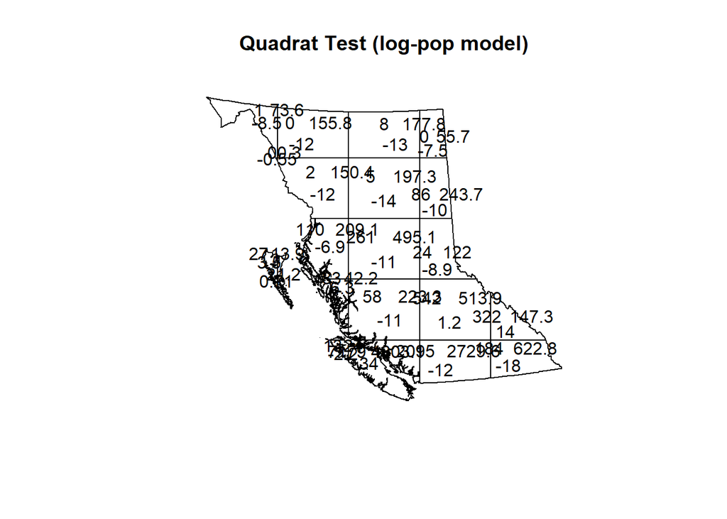

```r
plot(qtest_log, main = "Quadrat Test (log-pop model)")
```

```r
# Step 6: Residual diagnostics
par(mfrow = c(2, 2))
plot(model_pop_log, which = 1:4)

# Step 7: Visualize predicted log intensity
plot(predict(model_pop_log, n = 512),
     log = TRUE,
     main = "Predicted Log Intensity (log-pop model)")
plot(deer_ppp, add = TRUE, cols = "red", pch = ".")
# Step 8: Effect plot of log(population)
effectfun(model_pop_log, "pop", se.fit = FALSE,
          main = "Effect of Log(Population) on Log Intensity",
          xlab = "Log(Population + 1e-3)", ylab = "Log Intensity")
```

```
Function value object (class 'fv')
for the function pop -> lambda(pop)
..............................................
       Math.label       Description
pop    pop              value of covariate pop
lambda hat(lambda)(pop) fitted intensity
..............................................
Default plot formula:  lambda~pop
where "." stands for 'lambda'
Recommended range of argument pop: [-6.9078, 3.624]
Available range of argument pop: [-6.9078, 3.624]
```

[output not shown]

[figure not shown]

```r
# Step 9: Compare AIC with other models (if available)
AIC(model_pop, model_pop_log, model_fixed)
```

```r
AIC(model_pop)
```

```
[1] 217686.2
```

```r
AIC(model_pop_log)
```

```
[1] 351444.3
```

```r
AIC(model_fixed)
```

```
[1] 408013.1
```